# Comparison Between Experiments

```r
###################################################################################################
# Gene Expression data

# All Regions
load('./../../AllRegions/Data/preprocessed_data.RData')
datExpr_all = datExpr %>% data.frame
DE_info_all = DE_info %>% data.frame %>% mutate(ID = rownames(.))
datMeta_full = datMeta %>% dplyr::select(-matches('SV|Picard'))

# Frontal
load('./../../Frontal/Data/preprocessed_data.RData')
datExpr_frontal = datExpr %>% data.frame
DE_info_frontal = DE_info %>% data.frame %>% mutate(ID = rownames(.))
datMeta = datMeta %>% dplyr::select(-matches('SV|Picard'))
datMeta_full = rbind(datMeta_full, datMeta) %>% distinct(Sample_ID, .keep_all = TRUE)

# Occipital
load('./../../Occipital/Data/preprocessed_data.RData')
datExpr_occipital = datExpr %>% data.frame
DE_info_occipital = DE_info %>% data.frame %>% mutate(ID = rownames(.))
datMeta = datMeta %>% dplyr::select(-matches('SV|Picard'))
datMeta_full = rbind(datMeta_full, datMeta) %>% distinct(Sample_ID, .keep_all = TRUE)

# Without Occipital
load('./../../NoOccipital/Data/preprocessed_data.RData')
datExpr_no_occipital = datExpr %>% data.frame
DE_info_no_occipital = DE_info %>% data.frame %>% mutate(ID = rownames(.))
datMeta = datMeta %>% dplyr::select(-matches('SV|Picard'))
datMeta_full = rbind(datMeta_full, datMeta) %>% distinct(Sample_ID, .keep_all = TRUE)

# Get Entrez Gene ID for all genes
all_genes = unique(c(DE_info_all$ID, DE_info_frontal$ID,
                     DE_info_occipital$ID, DE_info_no_occipital$ID))
getinfo = c('ensembl_gene_id','entrezgene')
mart = useMart(biomart='ENSEMBL_MART_ENSEMBL', dataset='hsapiens_gene_ensembl', host='feb2014.archive.ensembl.org')
genes_EntrezGeneID = getBM(attributes=getinfo, filters=c('ensembl_gene_id'), values=all_genes, mart=mart)
colnames(genes_EntrezGeneID)[1] = 'ID'

###################################################################################################

# SFARI Genes
SFARI_genes = read_csv('./../../../SFARI/Data/SFARI_genes_08-29-2019_w_ensembl_IDs.csv')
SFARI_genes = SFARI_genes[!duplicated(SFARI_genes$ID) & !is.na(SFARI_genes$ID),]

###################################################################################################

# GO Neuronal annotations: regex 'neuron' in GO functional annotations and label the genes that make a match as neuronal
GO_annotations = read.csv('./../../AllRegions/Data/genes_GO_annotations.csv')
GO_neuronal = GO_annotations %>% filter(grepl('neuron', go_term)) %>%
              mutate('ID'=as.character(ensembl_gene_id)) %>%
              dplyr::select(-ensembl_gene_id) %>% distinct(ID) %>%
              mutate('Neuronal'=1)

###################################################################################################

# Prepare datasets for enrichment analysis
GO_col = buildGOcollection(organism = 'human', verbose = 0)
internal_col = internalCollection(organism = 'human')
MillerAIBS_col = MillerAIBSCollection(organism = 'human')
BrainDisease_col = BrainDiseaseCollection(organism = 'human')
combined_col = mergeCollections(GO_col, internal_col, MillerAIBS_col, BrainDisease_col)



rm(GO_annotations, datMeta, datExpr, datGenes, dds, DE_info, GO_col, internal_col, MillerAIBS_col,
   BrainDisease_col, getinfo, mart)
```

## Pool of Genes

The genes studied in each experiment were very similar

```r
all_genes = unique(genes_EntrezGeneID$ID)

genes_df = data.frame('All' = all_genes %in% DE_info_all$ID,
                      'Fro' = all_genes %in% DE_info_frontal$ID,
                      'Occ' = all_genes %in% DE_info_occipital$ID,
                      'NoO' = all_genes %in% DE_info_no_occipital$ID)

cat(paste0('Total number of genes: ', nrow(genes_df)))
```

```
## Total number of genes: 16563
```

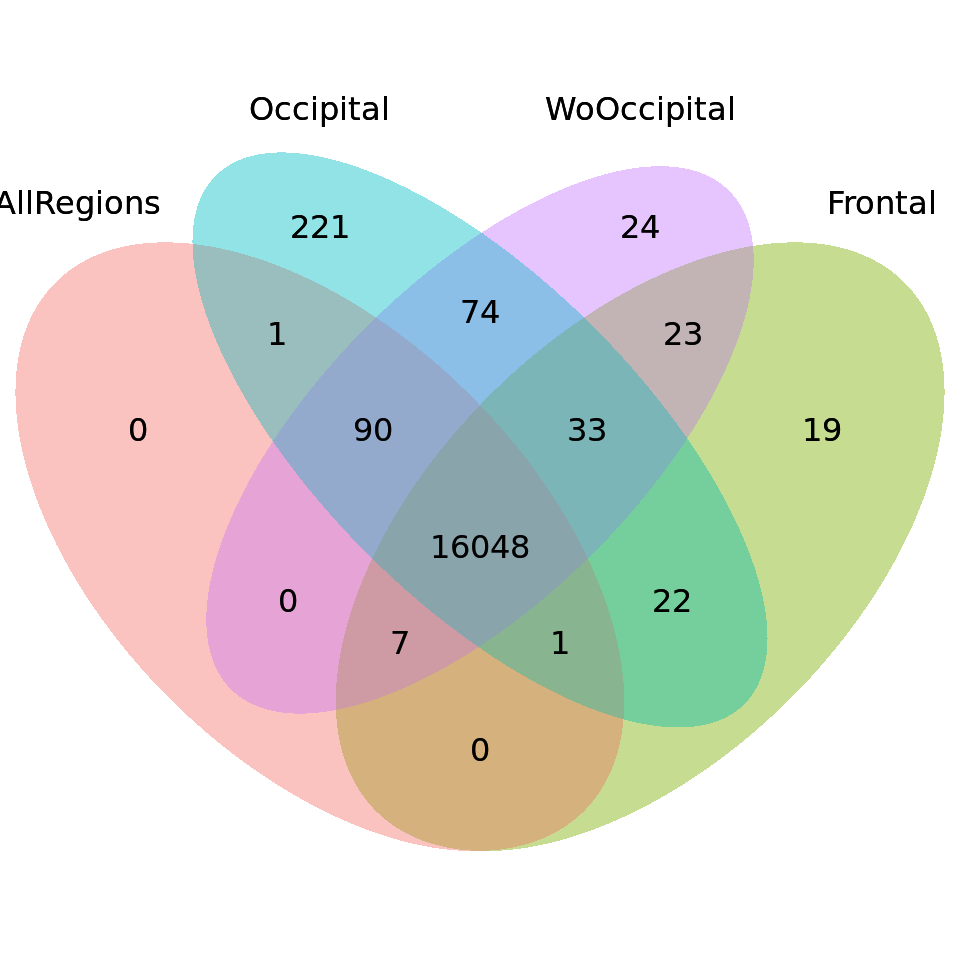

```r
grid.newpage()
grid.draw(draw.quad.venn(sum(genes_df$All), sum(genes_df$Fro), sum(genes_df$Occ), sum(genes_df$NoO),
          sum(genes_df$All*genes_df$Fro), sum(genes_df$All*genes_df$Occ), sum(genes_df$All*genes_df$NoO),
          sum(genes_df$Fro*genes_df$Occ), sum(genes_df$Fro*genes_df$NoO), sum(genes_df$Occ*genes_df$NoO),
          sum(genes_df$All*genes_df$Fro*genes_df$Occ), sum(genes_df$All*genes_df$Fro*genes_df$NoO),
          sum(genes_df$All*genes_df$Occ*genes_df$NoO), sum(genes_df$Fro*genes_df$Occ*genes_df$NoO),
          sum(genes_df$All*genes_df$Fro*genes_df$Occ*genes_df$NoO),
          category = c('AllRegions', 'Frontal', 'Occipital', 'WoOccipital'),
          fill = hcl(h=seq(15, 375, length=5), l=65, c=100)[-5], fontfamily = rep('sans-serif',15),
          alpha = rep(0.25,4), lty = rep('blank', 4), cat.fontfamily = rep('sans-serif',4)))
```

## DE Genes

### Analyse each experiment independently

```r
genes_df = data.frame('All' = all_genes %in% DE_info_all$ID[DE_info_all$padj<0.05],
                      'Fro' = all_genes %in% DE_info_frontal$ID[DE_info_frontal$padj<0.05],
                      'Occ' = all_genes %in% DE_info_occipital$ID[DE_info_occipital$padj<0.05],
                      'NoO' = all_genes %in% DE_info_no_occipital$ID[DE_info_no_occipital$padj<0.05],
                      'ID' = all_genes)
rownames(genes_df) = all_genes
genes_df = genes_df[genes_df$All+genes_df$Fro+genes_df$Occ+genes_df$NoO>0,]

cat(paste0('Total number of DE genes: ', nrow(genes_df)))
```

```
## Total number of DE genes: 7114
```

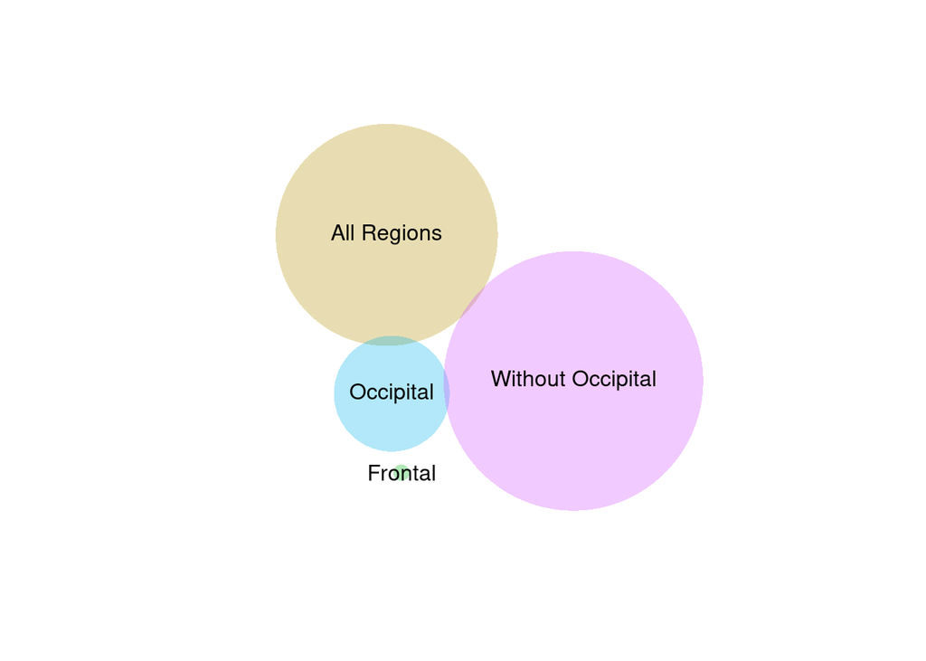

```r
plot(venneuler(combinations = c('All Regions'=sum(genes_df$All), 'Frontal'=sum(genes_df$Fro),
                                'Occipital'=sum(genes_df$Occ), 'Without Occipital'=sum(genes_df$NoO))))
```

#### 1. All Regions

```r
perform_enrichment = function(DE_info){

  EA_dataset = DE_info %>% left_join(genes_EntrezGeneID, by = 'ID')

  # Perform Enrichment Analysis
  enrichment = enrichmentAnalysis(classLabels = EA_dataset$DE, identifiers = EA_dataset$entrezgene,
                                  refCollection = combined_col, #useBackground = 'given',
                                  threshold = 1e-4, thresholdType = 'Bonferroni',
                                  getOverlapEntrez = FALSE, getOverlapSymbols = TRUE)

  enrichment_df = enrichment$enrichmentTable %>% filter(class==1) %>%
                  dplyr::select(dataSetID, shortDataSetName, inGroups, Bonferroni, FDR, enrichmentRatio,
                                effectiveClassSize, effectiveSetSize, nCommonGenes) %>%
                  filter(Bonferroni<0.05) %>% arrange(Bonferroni, desc(enrichmentRatio))

  return(enrichment_df)
}

enrichment_input = genes_df %>% mutate(DE = as.numeric(All == 1))
enrichment_df = perform_enrichment(enrichment_input)
```

```
##  enrichmentAnalysis: preparing data..
##   ..working on label set 1 ..
```

```r
kable(enrichment_df, caption = 'Enriched terms for dataset including All Brain Regions')
```

Enriched terms for dataset including All Brain Regions

| dataSetID | shortDataSetName | inGroups | Bonferroni | FDR | enrichmentRatio | effectiveClassSize | effectiveSetSize | nCommonGenes |
| --- | --- | --- | --- | --- | --- | --- | --- | --- |
| JAM:002769 | downAD_mitochondrion | JAM\|BrainLists\|BrainLists.Blalock_AD | 0.0000000 | 0.0000000 | 1.396112 | 4499 | 202 | 178 |
| JAM:002744 | Autism_differential_expression_across_at_least_one_comparison | JAM\|BrainLists\|BrainLists.Voineagu | 0.0003406 | 0.0001703 | 1.176528 | 4499 | 540 | 401 |
| GO:0009161 | ribonucleoside monophosphate metabolic process | GO\|GO.BP | 0.0218602 | 0.0052503 | 1.271062 | 4499 | 177 | 142 |
| GO:0006119 | oxidative phosphorylation | GO\|GO.BP | 0.0220202 | 0.0052503 | 1.391138 | 4499 | 82 | 72 |
| GO:0009126 | purine nucleoside monophosphate metabolic process | GO\|GO.BP | 0.0315020 | 0.0052503 | 1.271166 | 4499 | 172 | 138 |
| GO:0009167 | purine ribonucleoside monophosphate metabolic process | GO\|GO.BP | 0.0315020 | 0.0052503 | 1.271166 | 4499 | 172 | 138 |
| GO:0046034 | ATP metabolic process | GO\|GO.BP | 0.0488704 | 0.0067549 | 1.279669 | 4499 | 156 | 126 |

#### 2. Frontal

```r
enrichment_input = genes_df %>% mutate(DE = as.numeric(Fro == 1))
enrichment_df = perform_enrichment(enrichment_input)
```

```
##  enrichmentAnalysis: preparing data..
##   ..working on label set 1 ..
```

```r
kable(enrichment_df, caption = 'Enriched terms for the Frontal Lobe dataset')
```

Enriched terms for the Frontal Lobe dataset

| dataSetID | shortDataSetName | inGroups | Bonferroni | FDR | enrichmentRatio | effectiveClassSize | effectiveSetSize | nCommonGenes |
| --- | --- | --- | --- | --- | --- | --- | --- | --- |

#### 3. Occipital

```r
enrichment_input = genes_df %>% mutate(DE = as.numeric(Occ == 1))
enrichment_df = perform_enrichment(enrichment_input)
```

```
##  enrichmentAnalysis: preparing data..
##   ..working on label set 1 ..
```

```r
kable(enrichment_df, caption = 'Enriched terms for the Occipital Lobe dataset')
```

Enriched terms for the Occipital Lobe dataset

| dataSetID | shortDataSetName | inGroups | Bonferroni | FDR | enrichmentRatio | effectiveClassSize | effectiveSetSize | nCommonGenes |
| --- | --- | --- | --- | --- | --- | --- | --- | --- |
| JAM:002744 | Autism_differential_expression_across_at_least_one_comparison | JAM\|BrainLists\|BrainLists.Voineagu | 0.00e+00 | 0.0e+00 | 2.070471 | 1229 | 542 | 193 |
| JAM:002985 | Parietal Lobe_IN_Cerebral Cortex | JAM\|BrainRegionMarkers\|BrainRegionMarkers.HBA\|BrainRegionMarkers.HBA.localMarker(top200)\|Brain region markers\|Brain region marker enriched gene sets | 0.00e+00 | 0.0e+00 | 3.815755 | 1229 | 64 | 42 |
| JAMiller.AIBS.000506 | Genes bound by SUZ12 in MOUSE MESC from PMID 20075857 | JA Miller at AIBS\|Chip-X enrichment analysis (ChEA) | 0.00e+00 | 0.0e+00 | 1.393226 | 1229 | 1757 | 421 |
| JAM:002967 | Occipital Lobe_IN_Cerebral Cortex | JAM\|BrainRegionMarkers\|BrainRegionMarkers.HBA\|BrainRegionMarkers.HBA.localMarker(top200)\|Brain region markers\|Brain region marker enriched gene sets | 0.00e+00 | 0.0e+00 | 3.223246 | 1229 | 92 | 51 |
| JAMiller.AIBS.000364 | Genes bound by MTF2 in MOUSE MESC from PMID 20144788 | JA Miller at AIBS\|Chip-X enrichment analysis (ChEA) | 0.00e+00 | 0.0e+00 | 1.468255 | 1229 | 1192 | 301 |
| JAMiller.AIBS.000504 | Genes bound by SUZ12 in mouse MESC from PMID 18692474 | JA Miller at AIBS\|Chip-X enrichment analysis (ChEA) | 0.00e+00 | 0.0e+00 | 1.599177 | 1229 | 749 | 206 |
| JAM:002986 | parietal part, inferior bank of gyrus_IN_Cingulate Gyrus | JAM\|BrainRegionMarkers\|BrainRegionMarkers.HBA\|BrainRegionMarkers.HBA.localMarker(top200)\|Brain region markers\|Brain region marker enriched gene sets | 1.00e-07 | 0.0e+00 | 3.282370 | 1229 | 62 | 35 |
| JAMiller.AIBS.000505 | Genes bound by SUZ12 in MOUSE MESC from PMID 18974828 | JA Miller at AIBS\|Chip-X enrichment analysis (ChEA) | 3.00e-07 | 0.0e+00 | 1.541835 | 1229 | 758 | 201 |
| JAMiller.AIBS.000300 | Genes bound by EZH2 in MOUSE MESC from PMID 18974828 | JA Miller at AIBS\|Chip-X enrichment analysis (ChEA) | 4.00e-07 | 0.0e+00 | 1.682835 | 1229 | 501 | 145 |
| JAMiller.AIBS.000441 | Genes bound by RNF2 in MOUSE MESC from PMID 18974828 | JA Miller at AIBS\|Chip-X enrichment analysis (ChEA) | 4.00e-07 | 0.0e+00 | 1.682835 | 1229 | 501 | 145 |
| GO:0097458 | neuron part | GO\|GO.CC | 2.80e-06 | 2.0e-07 | 1.465015 | 1229 | 893 | 225 |
| GO:1902495 | transmembrane transporter complex | GO\|GO.CC | 4.90e-06 | 3.0e-07 | 2.172077 | 1229 | 174 | 65 |
| JAMiller.AIBS.000346 | Genes bound by JARID2 in MOUSE MESC from PMID 20064375 | JA Miller at AIBS\|Chip-X enrichment analysis (ChEA) | 5.40e-06 | 3.0e-07 | 1.727074 | 1229 | 404 | 120 |
| JAMiller.AIBS.000142 | Highest in CP of 13-16 post-conception weeks human | JA Miller at AIBS\|Brain\|Prenatal brain\|Markers of cortex layers\|Cortex\|Postmitotic brain | 7.70e-06 | 5.0e-07 | 1.499525 | 1229 | 760 | 196 |
| JAM:002807 | Cingulate Gyrus | JAM\|BrainRegionMarkers\|BrainRegionMarkers.HBA\|BrainRegionMarkers.HBA.globalMarker(top200)\|Brain region markers\|Brain region marker enriched gene sets | 9.40e-06 | 5.0e-07 | 2.678582 | 1229 | 89 | 41 |
| GO:0045202 | synapse | GO\|GO.CC | 1.41e-05 | 7.0e-07 | 1.532432 | 1229 | 664 | 175 |
| GO:1990351 | transporter complex | GO\|GO.CC | 1.52e-05 | 8.0e-07 | 2.123266 | 1229 | 178 | 65 |
| JAM:002731 | Amygdala | JAM\|BrainRegionMarkers\|BrainRegionMarkers.HBA\|BrainRegionMarkers.HBA.globalMarker(top200)\|Brain region markers\|Brain region marker enriched gene sets | 3.02e-05 | 1.3e-06 | 2.667822 | 1229 | 85 | 39 |
| GO:0042391 | regulation of membrane potential | GO\|GO.BP | 3.35e-05 | 1.3e-06 | 1.973241 | 1229 | 221 | 75 |
| GO:0034702 | ion channel complex | GO\|GO.CC | 5.14e-05 | 1.9e-06 | 2.140301 | 1229 | 163 | 60 |
| GO:0007399 | nervous system development | GO\|GO.BP | 6.13e-05 | 2.2e-06 | 1.366631 | 1229 | 1153 | 271 |
| GO:0022839 | ion gated channel activity | GO\|GO.MF | 6.98e-05 | 2.4e-06 | 2.111211 | 1229 | 168 | 61 |
| JAMiller.AIBS.000106 | Genes enriched in the hippocampal SGZ in mouse | JA Miller at AIBS\|Brain\|Postnatal brain\|Markers of cortex layers | 8.85e-05 | 3.0e-06 | 1.956024 | 1229 | 217 | 73 |

#### 4. Without Occipital

```r
enrichment_input = genes_df %>% mutate(DE = as.numeric(NoO == 1))
enrichment_df = perform_enrichment(enrichment_input)
```

```
##  enrichmentAnalysis: preparing data..
##   ..working on label set 1 ..
```

```r
kable(enrichment_df, caption = 'Enriched terms for dataset excluding the Occipital Lobe')
```

Enriched terms for dataset excluding the Occipital Lobe

| dataSetID | shortDataSetName | inGroups | Bonferroni | FDR | enrichmentRatio | effectiveClassSize | effectiveSetSize | nCommonGenes |
| --- | --- | --- | --- | --- | --- | --- | --- | --- |
| GO:0044424 | intracellular part | GO\|GO.CC | 0.0013200 | 0.0002114 | 1.012916 | 6172 | 5750 | 5041 |
| GO:0005622 | intracellular | GO\|GO.CC | 0.0014800 | 0.0002114 | 1.012839 | 6172 | 5755 | 5045 |
| GO:0044444 | cytoplasmic part | GO\|GO.CC | 0.0162482 | 0.0020310 | 1.019911 | 6172 | 4145 | 3659 |

### Analyse interactions between datasets

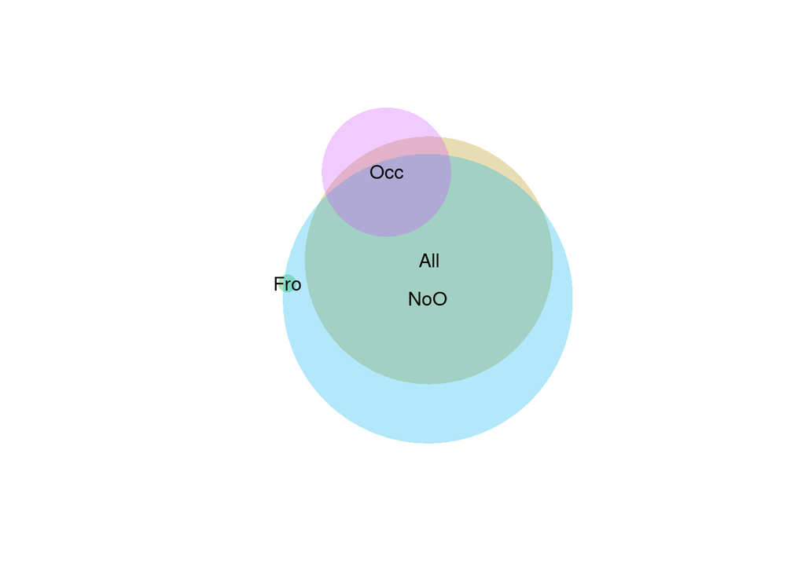

```r
plot(venneuler(genes_df[, colnames(genes_df) != 'ID']))
```

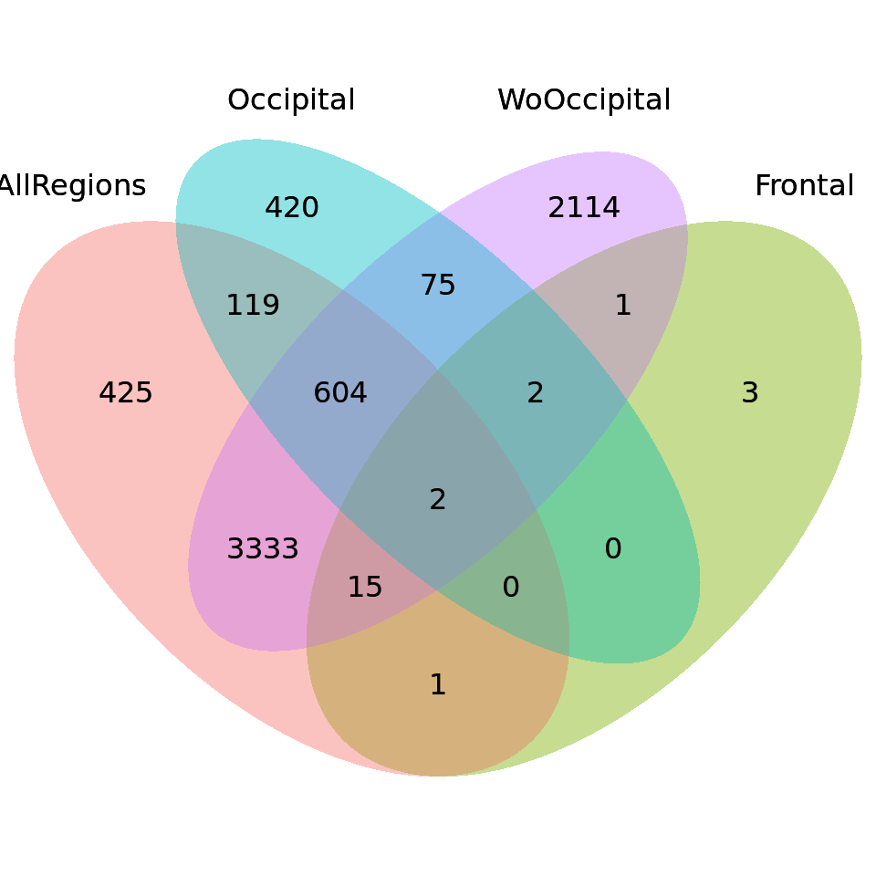

```r
grid.newpage()
grid.draw(draw.quad.venn(sum(genes_df$All), sum(genes_df$Fro), sum(genes_df$Occ), sum(genes_df$NoO),
          sum(genes_df$All*genes_df$Fro), sum(genes_df$All*genes_df$Occ), sum(genes_df$All*genes_df$NoO),
          sum(genes_df$Fro*genes_df$Occ), sum(genes_df$Fro*genes_df$NoO), sum(genes_df$Occ*genes_df$NoO),
          sum(genes_df$All*genes_df$Fro*genes_df$Occ), sum(genes_df$All*genes_df$Fro*genes_df$NoO),
          sum(genes_df$All*genes_df$Occ*genes_df$NoO), sum(genes_df$Fro*genes_df$Occ*genes_df$NoO),
          sum(genes_df$All*genes_df$Fro*genes_df$Occ*genes_df$NoO),
          category = c('AllRegions', 'Frontal', 'Occipital', 'WoOccipital'),
          fill = hcl(h=seq(15, 375, length=5), l=65, c=100)[-5], fontfamily = rep('sans-serif',15),
          alpha = rep(0.25,4), lty = rep('blank', 4), cat.fontfamily = rep('sans-serif',4)))
```

```r
getinfo = c('ensembl_gene_id','external_gene_id')
mart = useMart(biomart='ENSEMBL_MART_ENSEMBL', dataset='hsapiens_gene_ensembl', host='feb2014.archive.ensembl.org')
common_DE_genes = getBM(attributes=getinfo, filters=c('ensembl_gene_id'),
                        values=rownames(genes_df)[genes_df$All*genes_df$Fro*genes_df$Occ*genes_df$NoO>0],
                        mart=mart)
```

```
## Cache found
```

```r
common_DE_genes = common_DE_genes %>% dplyr::rename('gene_symbol' = 'external_gene_id') %>%
                  left_join(SFARI_genes, by=c('ensembl_gene_id'='ID')) %>%
                  dplyr::select(ensembl_gene_id, gene_symbol, `gene-score`, syndromic)

kable(common_DE_genes, caption = 'Genes found to be DE in all four experiments')
```

Genes found to be DE in all four experiments

| ensembl_gene_id | gene_symbol | gene-score | syndromic |
| --- | --- | --- | --- |
| ENSG00000136869 | TLR4 | NA | NA |
| ENSG00000144406 | UNC80 | 4 | 0 |

### Analyse interactions between datasets without Frontal Lobe experiment

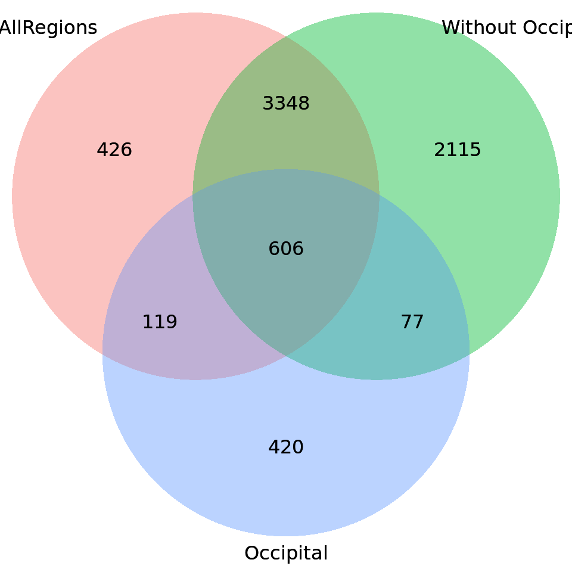

```r
grid.newpage()
grid.draw(draw.triple.venn(sum(genes_df$All), sum(genes_df$NoO), sum(genes_df$Occ),
                           sum(genes_df$All*genes_df$NoO), sum(genes_df$Occ*genes_df$NoO), sum(genes_df$All*genes_df$Occ),
                           sum(genes_df$All*genes_df$NoO*genes_df$Occ),
          category = c('AllRegions', 'Without Occipital', 'Occipital'),
          fill = hcl(h=seq(15, 375, length=4), l=65, c=100)[-4], fontfamily = rep('sans-serif',7),
          alpha = rep(0.25,3), lty = rep('blank', 3), cat.fontfamily = rep('sans-serif',3)))
```

#### 1. DE in All Regions dataset only

These genes are DE only when analysing the whole dataset (not when studying the Occipital Lobe, nor when removing it and studying the rest), so they need information from all areas together to be significant enough

```r
enrichment_input = genes_df %>% filter(All) %>% mutate(DE = as.numeric(NoO + Occ == 0))
enrichment_df = perform_enrichment(enrichment_input)
```

```
##  enrichmentAnalysis: preparing data..
##   ..working on label set 1 ..
```

```r
kable(enrichment_df, caption = 'Enriched terms only in the All Regions dataset')
```

Enriched terms only in the All Regions dataset

| dataSetID | shortDataSetName | inGroups | Bonferroni | FDR | enrichmentRatio | effectiveClassSize | effectiveSetSize | nCommonGenes |
| --- | --- | --- | --- | --- | --- | --- | --- | --- |
| GO:0035082 | axoneme assembly | GO\|GO.BP | 0.0319499 | 0.0319499 | 7.819913 | 420 | 11 | 8 |

#### 2. DE in Occipital Lobe dataset only

These genes are DE only when analysing the Occipital Lobe alone, so they are not enriched in the other regions and the signal is not strong enough to survive when adding other brain regions

```r
enrichment_input = genes_df %>% filter(Occ) %>% mutate(DE = as.numeric(All + NoO == 0))
enrichment_df = perform_enrichment(enrichment_input)
```

```
##  enrichmentAnalysis: preparing data..
##   ..working on label set 1 ..
```

```r
kable(enrichment_df, caption = 'Enriched terms only for the dataset studying the Occipital Lobe')
```

Enriched terms only for the dataset studying the Occipital Lobe

| dataSetID | shortDataSetName | inGroups | Bonferroni | FDR | enrichmentRatio | effectiveClassSize | effectiveSetSize | nCommonGenes |
| --- | --- | --- | --- | --- | --- | --- | --- | --- |